# Untitled

Arina

2025-02-08

#Задание 1. Оценка физической активности пациентов Vigorous work activity (PAQ605)- активная трудовая деятельность PAQ610 - Number of days vigorous work PAD615 - Minutes vigorous-intensity work PAQ620 - Moderate work activity PAQ625 - Number of days moderate work PAD630 - Minutes moderate-intensity work PAQ635 - Walk or bicycle PAQ640 - Number of days walk or bicycle PAD645 - Minutes walk/bicycle for transportation PAQ650 - Vigorous recreational activities PAQ655 - Days vigorous recreational activities PAD660 - Minutes vigorous recreational activities PAQ665 - Moderate recreational activities PAQ670 - Days moderate recreational activities PAD675 - Minutes moderate recreational activities PAD680 - Minutes sedentary activity

Физическую активность буду измерять на основе имеющихся переменных по какой-либо нагрузке (физ. активности) пациентов. Количество дней физической активности умножила на количество минут физической активности в день. Таким образом получила датасет с переменными в минутах. Для удобства лучше перевести в часы.

Гипотеза: при увеличении физической нагрузки уменьшается показатель гликированного гемоглобина

Чтобы оценивать влияние физической активности на гликированный геомглобин, нужна общая переменная по физической нагрузке: низкая активность, умеренная и высокая. Таким образом, мы должны будем увидеть некую зависимость между уровнем гликированного геомглобина и увеличением нагрузки. Так как категоризировать гликированный геоглобин нельзя, то категоризируем физ. нагрузку. Сложим для каждого пациента все часы физ нагрузки и разобъем по категориям.

```
## [1] 90
```

#Задание 2. Ковариаты Согласно представленному DAG есть следующие показатели: -раса (конфаундер, так как влияет и зависимую переменную - гликированный гемоглобин,так и на независимые переменные) -пол (конфаундер) -Образование (конфаундер) -Возраст (конфаундер) -Курение (конфаундер) -Семейный доход (влияет только на независимую переменную, конфаундер) -Сопутствующие заболевания (конфаундер) -Индекс массы тела (медиатор - физическая активность влияет на гликированный геоглобин посредством индекса массы тела) -Кровяное давление (коллайдер - на давление оказывает влияние как гликированный геомглобин, так и наличие физической нагрузки) -Лечение диабета (коллайдер) -Семейное положение (нейтральная переменная)

В качестве ковариат для использования в модели были выбраны перменные, которые могут оказывать влияние на гликированный геомглобин (не включаем коллайдеры и медиаторы): -Раса -Пол -образование -возраст -семейный доход -Сопутствующие заболевания -Курение

Согласно спецификации:

Объединим два датасета с ковариатами, физической нагрузки и добавим зависимую переменнную - гликированный геомглобин (для дальнейшей работы)

#Задание 3. Эксплораторный анализ Для того, чтобы лучше понимать переменнные по физ нагрузкеи и полученную общую переменную, которая была фактически произвольно разделена на подгруппы, нужно посмотреть распределение

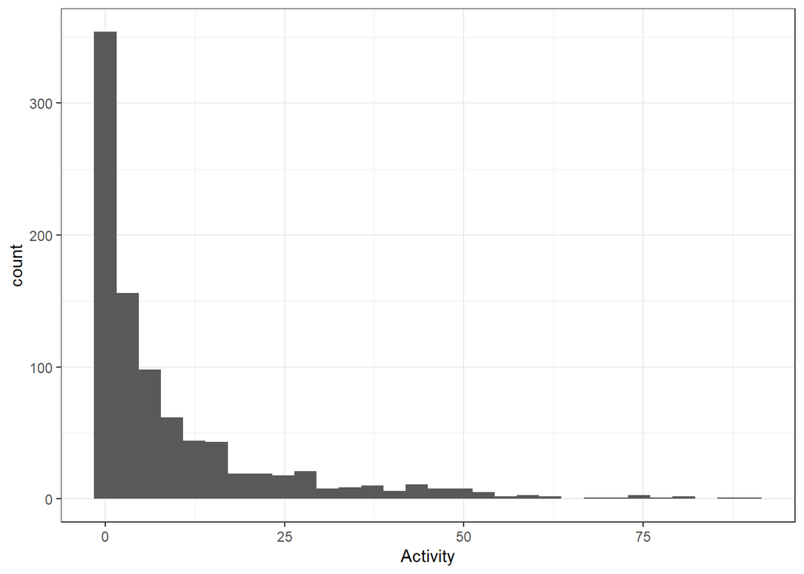

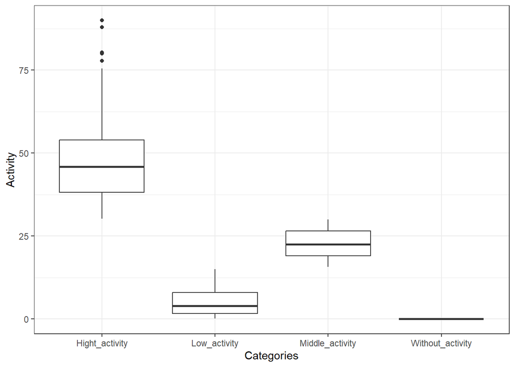

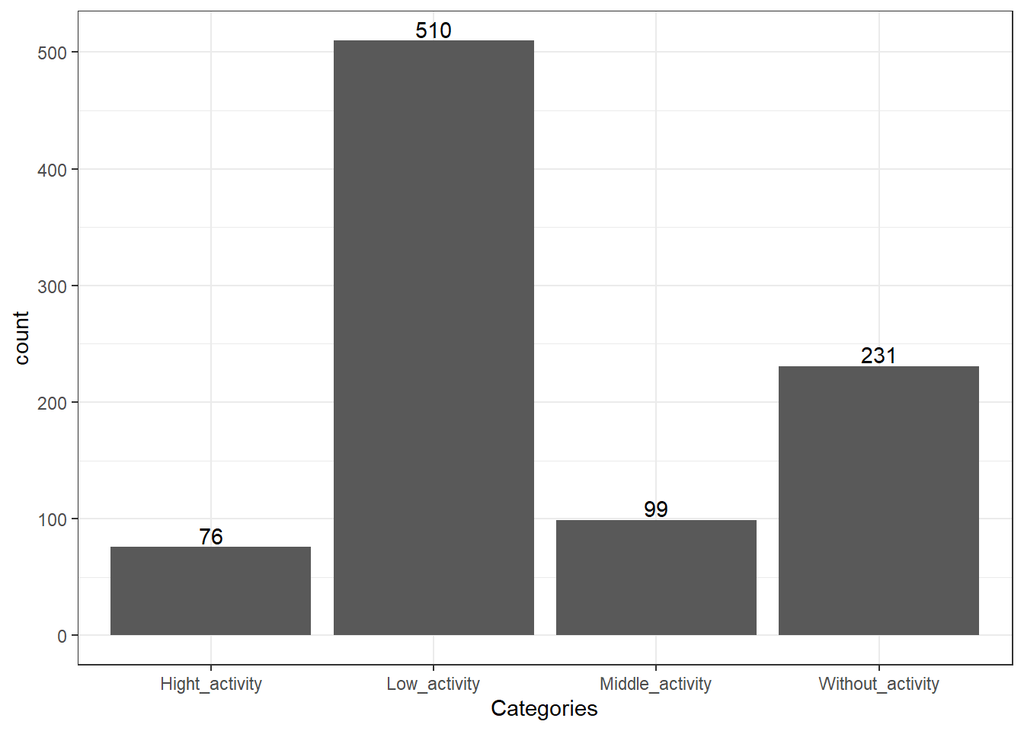

#Посмотрим, есть ли корреляции и как распредлеяется физическая нагрузка для категориальных переменных

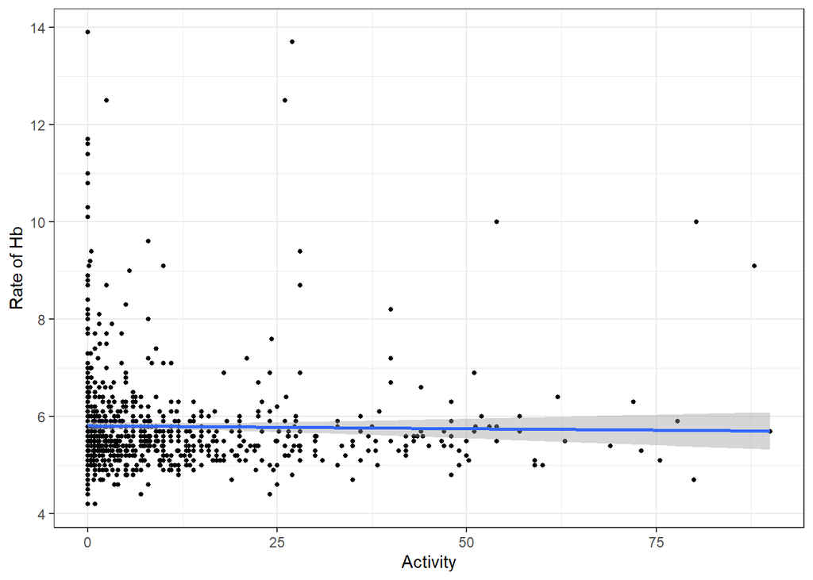

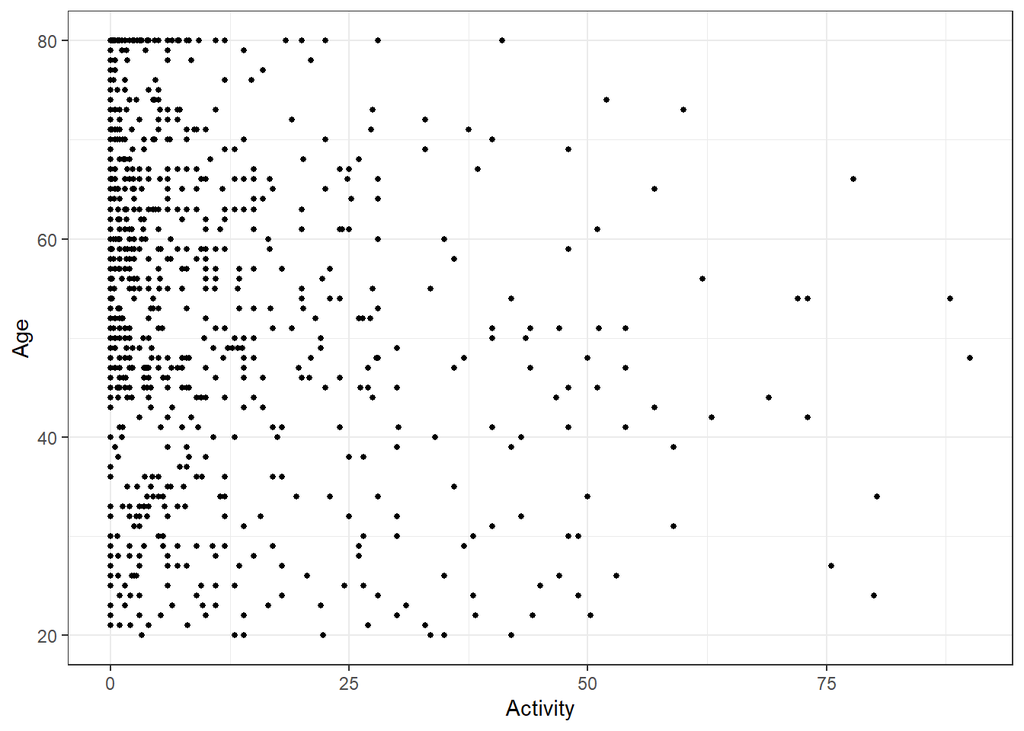

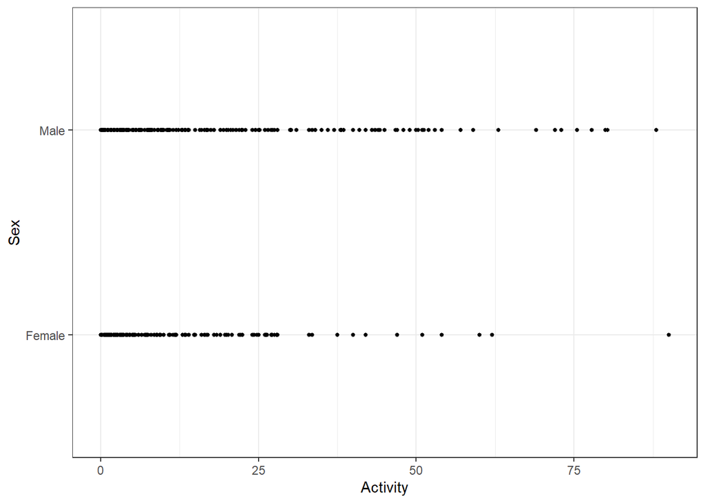

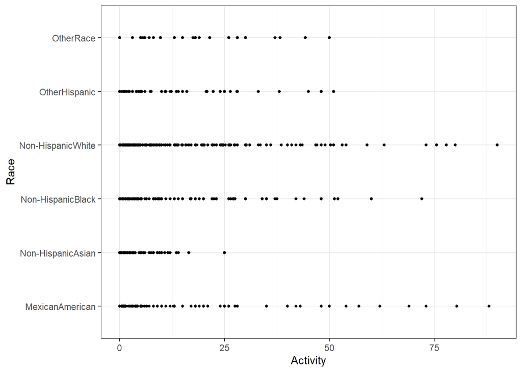

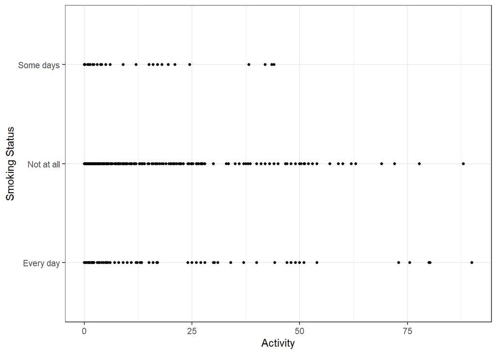

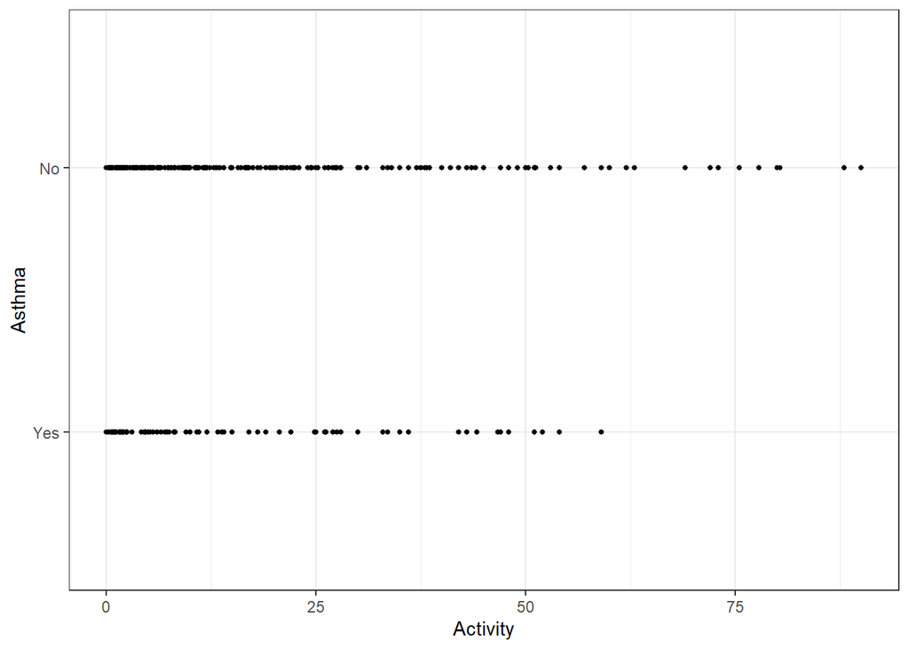

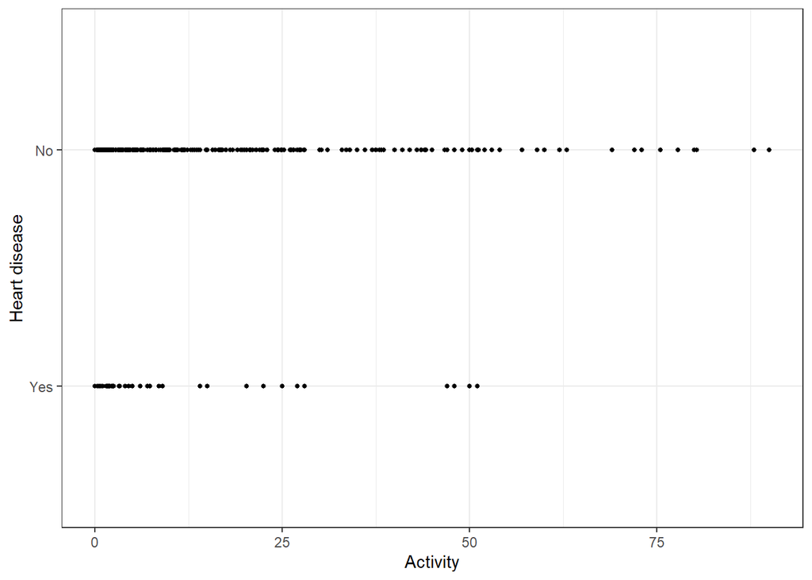

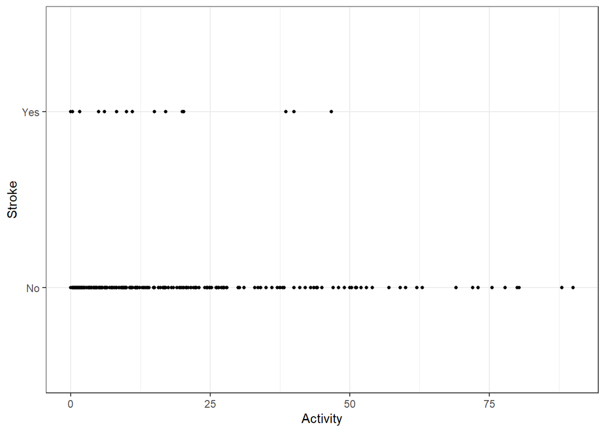

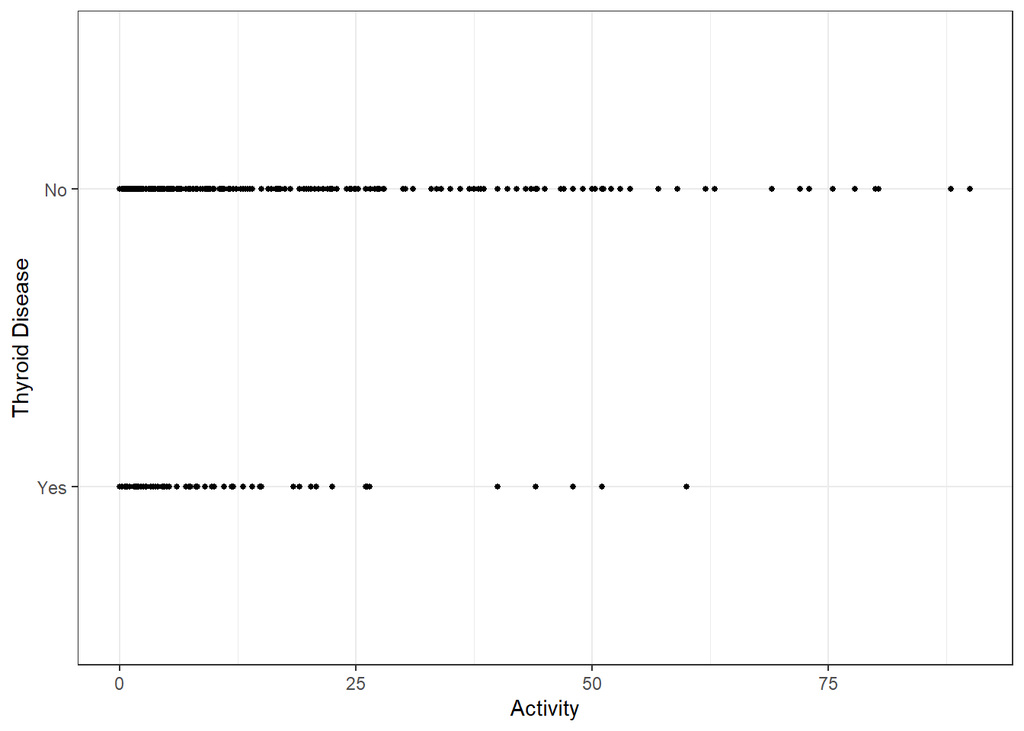

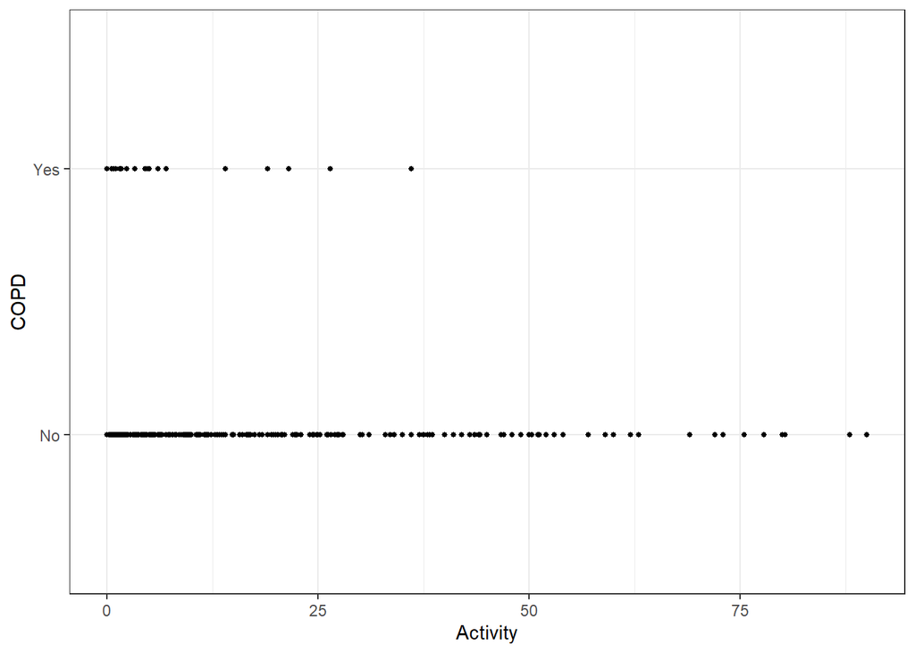

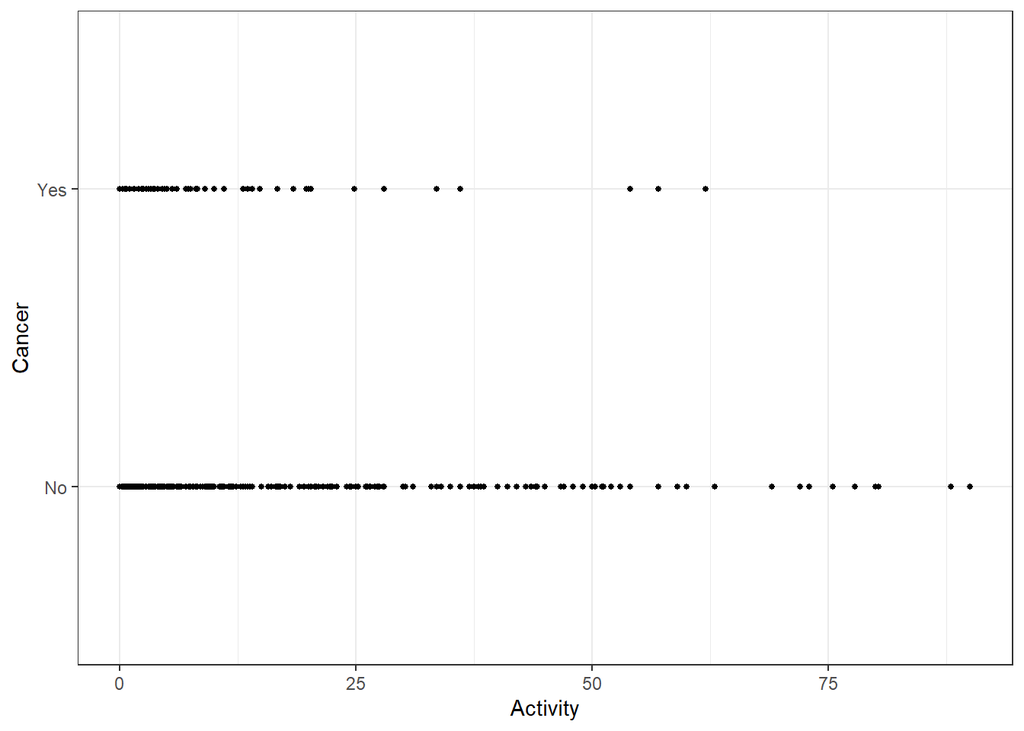

| **Characteristic** | **N = 916** |
| --- | --- |
| Activity |  |
| N Non-missing | 916 |
| Mean (SD) | 9 (14) |
| Median (Q1-Q3) | 4 (0-12) |
| Min-Max | 0-90 |
| Categories |  |
| Hight_activity | 76 (8.3%) |
| Low_activity | 510 (56%) |
| Middle_activity | 99 (11%) |
| Without_activity | 231 (25%) |
| Race |  |
| MexicanAmerican | 101 (11%) |
| Non-HispanicAsian | 78 (8.5%) |
| Non-HispanicBlack | 175 (19%) |
| Non-HispanicWhite | 463 (51%) |
| OtherHispanic | 75 (8.2%) |
| OtherRace | 24 (2.6%) |
| FamilyIncome |  |
| $ 0 to $ 4,999 | 23 (2.5%) |
| $ 5,000 to $ 9,999 | 36 (3.9%) |
| $10,000 to $14,999 | 69 (7.5%) |
| $100,000 and Over | 179 (20%) |
| $15,000 to $19,999 | 78 (8.5%) |
| $20,000 to $24,999 | 73 (8.0%) |
| $25,000 to $34,999 | 104 (11%) |
| $35,000 to $44,999 | 100 (11%) |
| $45,000 to $54,999 | 78 (8.5%) |
| $55,000 to $64,999 | 54 (5.9%) |
| $65,000 to $74,999 | 49 (5.3%) |
| $75,000 to $99,999 | 73 (8.0%) |
| Age |  |
| N Non-missing | 916 |
| Mean (SD) | 55 (16) |
| Median (Q1-Q3) | 56 (45-67) |
| Min-Max | 20-80 |
| Sex |  |
| Female | 377 (41%) |
| Male | 539 (59%) |
| SmokingStatus |  |
| Every day | 133 (15%) |
| Not at all | 752 (82%) |
| Some days | 31 (3.4%) |
| Asthma | 144 (16%) |
| Heart_disease | 77 (8.4%) |
| Stroke | 32 (3.5%) |
| ThyroidDisease | 128 (14%) |
| COPD | 39 (4.3%) |
| Cancer | 104 (11%) |
| Hb |  |
| N Non-missing | 916 |
| Mean (SD) | 5.80 (1.04) |
| Median (Q1-Q3) | 5.60 (5.30-5.90) |
| Min-Max | 4.20-13.90 |

#Задание 4. Регрессионный анализ ##Без ковариат (для категорий физ активности)

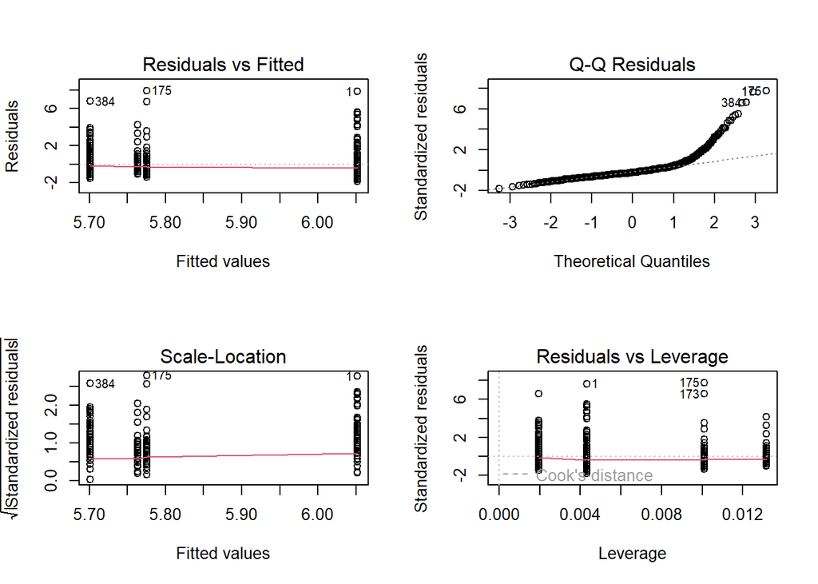

```
##
## Call:
## lm(formula = Hb ~ Categories, data = ready_data)
##
## Coefficients:
##                (Intercept)      CategoriesLow_activity
##                    5.76316                    -0.06218
##  CategoriesMiddle_activity  CategoriesWithout_activity
##                    0.01260                     0.28836
```

```
##                (Intercept)     CategoriesLow_activity
##                 5.76315789                -0.06217750
##  CategoriesMiddle_activity CategoriesWithout_activity
##                 0.01259968                 0.28835726
```

```
##                                  2.5 %    97.5 %
## (Intercept)                 5.53213159 5.9941842
## CategoriesLow_activity     -0.30981998 0.1854650
## CategoriesMiddle_activity  -0.29455904 0.3197584
## CategoriesWithout_activity  0.02202448 0.5546900
```

```
##
## Call:
## lm(formula = Hb ~ Categories, data = ready_data)
##
## Residuals:
##    Min     1Q Median     3Q    Max
## -1.851 -0.501 -0.201  0.199  7.924
##
## Coefficients:
##                            Estimate Std. Error t value Pr(>|t|)
## (Intercept)                 5.76316    0.11772  48.958   <2e-16 ***
## CategoriesLow_activity     -0.06218    0.12618  -0.493   0.6223
## CategoriesMiddle_activity   0.01260    0.15651   0.081   0.9359
## CategoriesWithout_activity  0.28836    0.13571   2.125   0.0339 *
## ---
## Signif. codes:  0 '***' 0.001 '**' 0.01 '*' 0.05 '.' 0.1 ' ' 1
##
## Residual standard error: 1.026 on 912 degrees of freedom
## Multiple R-squared:  0.02017,    Adjusted R-squared:  0.01694
## F-statistic: 6.257 on 3 and 912 DF,  p-value: 0.0003322
```

```
## # A tibble: 4 × 7
##   term                 estimate std.error statistic   p.value conf.low conf.high
##   <chr>                   <dbl>     <dbl>     <dbl>     <dbl>    <dbl>     <dbl>
## 1 (Intercept)            5.76       0.118   49.0    1.88e-257   5.53       5.99
## 2 CategoriesLow_activ…  -0.0622     0.126   -0.493  6.22e-  1  -0.310      0.185
## 3 CategoriesMiddle_ac…   0.0126     0.157    0.0805 9.36e-  1  -0.295      0.320
## 4 CategoriesWithout_a…   0.288      0.136    2.12   3.39e-  2   0.0220     0.555
```

Видно, что для низкой и средней физической активности результаты статистически незначимы. Есть стат значимость для пациентов без какой-либо активности. То есть при остутствии физической активности, увеличивается уровень гликированного геомглобина. R2 = 0.02 - модель очень плохо объясняет данные. Есть некоторое влияние физ нагрузки на уровень гликированного гемоглобина (p-value = 0.0339 для CategoriesWithout_activity)

По полученным графикам можно сказать, что распределение отлично от нормального по QQ-plot. Остальное оценить не можем, так как категориальная переменная.

#С переменной activity (без деления на категории)

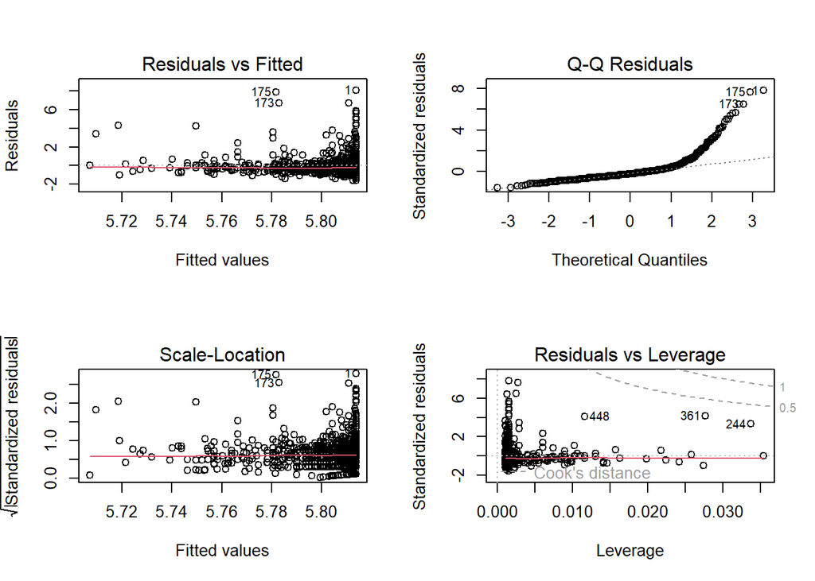

```
##
## Call:
## lm(formula = Hb ~ Activity, data = ready_data)
##
## Coefficients:
## (Intercept)     Activity
##    5.813753    -0.001186
```

```
##  (Intercept)     Activity
##  5.813753382 -0.001185687
```

```
##                    2.5 %      97.5 %
## (Intercept)  5.733558162 5.893948602
## Activity    -0.005855808 0.003484433
```

```
##
## Call:
## lm(formula = Hb ~ Activity, data = ready_data)
##
## Residuals:
##     Min      1Q  Median      3Q     Max
## -1.6138 -0.5114 -0.2138  0.1205  8.0862
##
## Coefficients:
##              Estimate Std. Error t value Pr(>|t|)
## (Intercept)  5.813753   0.040862 142.276   <2e-16 ***
## Activity    -0.001186   0.002380  -0.498    0.618
## ---
## Signif. codes:  0 '***' 0.001 '**' 0.01 '*' 0.05 '.' 0.1 ' ' 1
##
## Residual standard error: 1.035 on 914 degrees of freedom
## Multiple R-squared:  0.0002716,  Adjusted R-squared:  -0.0008222
## F-statistic: 0.2483 on 1 and 914 DF,  p-value: 0.6184
```

```
## # A tibble: 2 × 7
##   term        estimate std.error statistic p.value conf.low conf.high
##   <chr>          <dbl>     <dbl>     <dbl>   <dbl>    <dbl>     <dbl>
## 1 (Intercept)  5.81      0.0409    142.      0      5.73      5.89
## 2 Activity    -0.00119   0.00238    -0.498   0.618 -0.00586   0.00348
```

По p-value можно сказать, что нет значимого эффекта физ активности на уровень гемоглобина. Но по графику scale-location видно, что образуется “рукав”. Это говорит о гетероскедастичности и возможной нелинейной зависимости. О нелинейности так же говорят другие графики.

R2 равен 0.00027, => плохая модель

#Сделаем поправку на гетероскедастичность

| term | estimate | std.error | statistic | p.value | conf.low | conf.high |
| --- | --- | --- | --- | --- | --- | --- |
| (Intercept) | 5.813753 | 0.043497 | 133.657620 | 0.000000 | 5.728387 | 5.899120 |
| Activity | -0.001186 | 0.003047 | -0.389188 | 0.697227 | -0.007165 | 0.004793 |

#Поправка на гетероскедастичность и линейность (по распредлению гемоглобина от физ нагрузки допустим, что функция квадратичная)

```
##
## Call:
## lm(formula = Hb ~ Activity + I(Activity^2), data = ready_data)
##
## Residuals:
##     Min      1Q  Median      3Q     Max
## -1.8257 -0.5111 -0.2141  0.1429  8.0940
##
## Coefficients:
##                 Estimate Std. Error t value Pr(>|t|)
## (Intercept)    5.8854991  0.0456145 129.027  < 2e-16 ***
## Activity      -0.0197022  0.0058553  -3.365 0.000798 ***
## I(Activity^2)  0.0003463  0.0001002   3.457 0.000571 ***
## ---
## Signif. codes:  0 '***' 0.001 '**' 0.01 '*' 0.05 '.' 0.1 ' ' 1
##
## Residual standard error: 1.029 on 913 degrees of freedom
## Multiple R-squared:  0.01319,    Adjusted R-squared:  0.01103
## F-statistic: 6.101 on 2 and 913 DF,  p-value: 0.002333
```

```
##
## t test of coefficients:
##
##                  Estimate  Std. Error  t value  Pr(>|t|)
## (Intercept)    5.88549910  0.05107135 115.2407 < 2.2e-16 ***
## Activity      -0.01970222  0.00754177  -2.6124  0.009138 **
## I(Activity^2)  0.00034631  0.00014723   2.3521  0.018878 *
## ---
## Signif. codes:  0 '***' 0.001 '**' 0.01 '*' 0.05 '.' 0.1 ' ' 1
```

R2 значительно увеличился и стал 0.013. При этом влияние активности на уровень гликированного гемолглобина стало значимым. p-value < 0,05 (0,002)

##Построим модель с ковариатами (для категорий физ нагрузки)

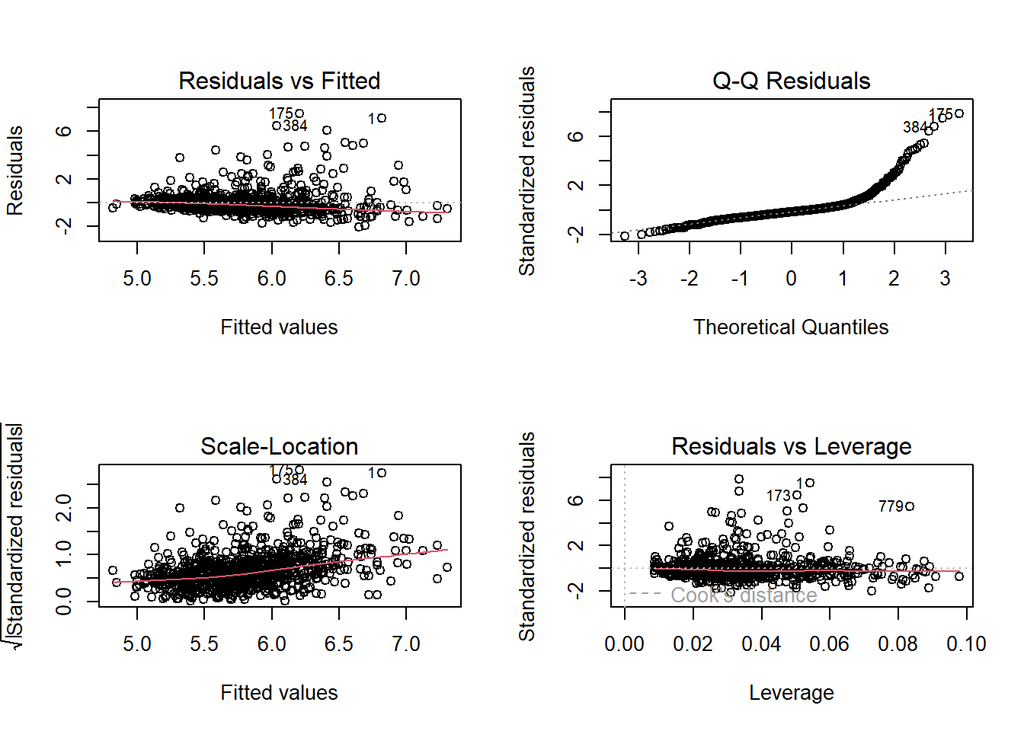

```
##
## Call:
## lm(formula = Hb ~ Categories + Sex + Age + FamilyIncome + Race +
##     SmokingStatus + Asthma + Heart_disease + Stroke + ThyroidDisease +
##     COPD + Cancer, data = ready_data)
##
## Coefficients:
##                    (Intercept)          CategoriesLow_activity
##                       5.805079                       -0.230075
##      CategoriesMiddle_activity      CategoriesWithout_activity
##                      -0.062775                        0.018468
##                        SexMale                             Age
##                       0.014267                        0.012413
## FamilyIncome$ 5,000 to $ 9,999  FamilyIncome$10,000 to $14,999
##                       0.491159                        0.350916
##  FamilyIncome$100,000 and Over  FamilyIncome$15,000 to $19,999
##                       0.291815                        0.370802
## FamilyIncome$20,000 to $24,999  FamilyIncome$25,000 to $34,999
##                       0.176374                        0.408479
## FamilyIncome$35,000 to $44,999  FamilyIncome$45,000 to $54,999
##                       0.147357                        0.275104
## FamilyIncome$55,000 to $64,999  FamilyIncome$65,000 to $74,999
##                       0.542764                        0.409839
## FamilyIncome$75,000 to $99,999           RaceNon-HispanicAsian
##                       0.126241                       -0.085181
##          RaceNon-HispanicBlack           RaceNon-HispanicWhite
##                      -0.008163                       -0.437504
##              RaceOtherHispanic                   RaceOtherRace
##                      -0.273619                       -0.490200
##        SmokingStatusNot at all          SmokingStatusSome days
##                      -0.042717                       -0.055188
##                       AsthmaNo                 Heart_diseaseNo
##                      -0.027021                       -0.635124
##                      StrokeYes                ThyroidDiseaseNo
##                       0.424112                        0.038167
##                        COPDYes                       CancerYes
##                      -0.258058                        0.106070
```

```
##                    (Intercept)         CategoriesLow_activity
##                    5.805078560                   -0.230074950
##      CategoriesMiddle_activity     CategoriesWithout_activity
##                   -0.062774553                    0.018468306
##                        SexMale                            Age
##                    0.014267128                    0.012413329
## FamilyIncome$ 5,000 to $ 9,999 FamilyIncome$10,000 to $14,999
##                    0.491158820                    0.350916443
##  FamilyIncome$100,000 and Over FamilyIncome$15,000 to $19,999
##                    0.291815164                    0.370802071
## FamilyIncome$20,000 to $24,999 FamilyIncome$25,000 to $34,999
##                    0.176374003                    0.408478893
## FamilyIncome$35,000 to $44,999 FamilyIncome$45,000 to $54,999
##                    0.147356602                    0.275103557
## FamilyIncome$55,000 to $64,999 FamilyIncome$65,000 to $74,999
##                    0.542764225                    0.409839424
## FamilyIncome$75,000 to $99,999          RaceNon-HispanicAsian
##                    0.126240932                   -0.085181002
##          RaceNon-HispanicBlack          RaceNon-HispanicWhite
##                   -0.008163428                   -0.437503927
##              RaceOtherHispanic                  RaceOtherRace
##                   -0.273618834                   -0.490200150
##        SmokingStatusNot at all         SmokingStatusSome days
##                   -0.042717442                   -0.055188086
##                       AsthmaNo                Heart_diseaseNo
##                   -0.027020895                   -0.635123626
##                      StrokeYes               ThyroidDiseaseNo
##                    0.424112343                    0.038166654
##                        COPDYes                      CancerYes
##                   -0.258057982                    0.106069740
```

```
##
## Call:
## lm(formula = Hb ~ Categories + Sex + Age + FamilyIncome + Race +
##     SmokingStatus + Asthma + Heart_disease + Stroke + ThyroidDisease +
##     COPD + Cancer, data = ready_data)
##
## Residuals:
##     Min      1Q  Median      3Q     Max
## -2.0491 -0.4654 -0.1554  0.1604  7.4921
##
## Coefficients:
##                                 Estimate Std. Error t value Pr(>|t|)
## (Intercept)                     5.805079   0.329791  17.602  < 2e-16 ***
## CategoriesLow_activity         -0.230075   0.124824  -1.843   0.0656 .
## CategoriesMiddle_activity      -0.062775   0.150294  -0.418   0.6763
## CategoriesWithout_activity      0.018468   0.136156   0.136   0.8921
## SexMale                         0.014267   0.073902   0.193   0.8470
## Age                             0.012413   0.002411   5.148 3.24e-07 ***
## FamilyIncome$ 5,000 to $ 9,999  0.491159   0.261384   1.879   0.0606 .
## FamilyIncome$10,000 to $14,999  0.350916   0.235608   1.489   0.1367
## FamilyIncome$100,000 and Over   0.291815   0.221481   1.318   0.1880
## FamilyIncome$15,000 to $19,999  0.370802   0.232654   1.594   0.1113
## FamilyIncome$20,000 to $24,999  0.176374   0.233805   0.754   0.4508
## FamilyIncome$25,000 to $34,999  0.408479   0.227076   1.799   0.0724 .
## FamilyIncome$35,000 to $44,999  0.147357   0.228139   0.646   0.5185
## FamilyIncome$45,000 to $54,999  0.275104   0.235715   1.167   0.2435
## FamilyIncome$55,000 to $64,999  0.542764   0.244719   2.218   0.0268 *
## FamilyIncome$65,000 to $74,999  0.409839   0.249855   1.640   0.1013
## FamilyIncome$75,000 to $99,999  0.126241   0.236231   0.534   0.5932
## RaceNon-HispanicAsian          -0.085181   0.153132  -0.556   0.5782
## RaceNon-HispanicBlack          -0.008163   0.123137  -0.066   0.9472
## RaceNon-HispanicWhite          -0.437504   0.110453  -3.961 8.06e-05 ***
## RaceOtherHispanic              -0.273619   0.150085  -1.823   0.0686 .
## RaceOtherRace                  -0.490200   0.225194  -2.177   0.0298 *
## SmokingStatusNot at all        -0.042717   0.097117  -0.440   0.6601
## SmokingStatusSome days         -0.055188   0.196228  -0.281   0.7786
## AsthmaNo                       -0.027021   0.090265  -0.299   0.7647
## Heart_diseaseNo                -0.635124   0.127694  -4.974 7.88e-07 ***
## StrokeYes                       0.424112   0.180375   2.351   0.0189 *
## ThyroidDiseaseNo                0.038167   0.099573   0.383   0.7016
## COPDYes                        -0.258058   0.173148  -1.490   0.1365
## CancerYes                       0.106070   0.108752   0.975   0.3297
## ---
## Signif. codes:  0 '***' 0.001 '**' 0.01 '*' 0.05 '.' 0.1 ' ' 1
##
## Residual standard error: 0.9681 on 886 degrees of freedom
## Multiple R-squared:  0.1528, Adjusted R-squared:  0.1251
## F-statistic: 5.512 on 29 and 886 DF,  p-value: < 2.2e-16
```

```
## # A tibble: 30 × 7
##    term                 estimate std.error statistic  p.value conf.low conf.high
##    <chr>                   <dbl>     <dbl>     <dbl>    <dbl>    <dbl>     <dbl>
##  1 (Intercept)            5.81     0.330      17.6   1.06e-59  5.16       6.45
##  2 CategoriesLow_activ…  -0.230    0.125      -1.84  6.56e- 2 -0.475      0.0149
##  3 CategoriesMiddle_ac…  -0.0628   0.150      -0.418 6.76e- 1 -0.358      0.232
##  4 CategoriesWithout_a…   0.0185   0.136       0.136 8.92e- 1 -0.249      0.286
##  5 SexMale                0.0143   0.0739      0.193 8.47e- 1 -0.131      0.159
##  6 Age                    0.0124   0.00241     5.15  3.24e- 7  0.00768    0.0171
##  7 FamilyIncome$ 5,000…   0.491    0.261       1.88  6.06e- 2 -0.0218     1.00
##  8 FamilyIncome$10,000…   0.351    0.236       1.49  1.37e- 1 -0.111      0.813
##  9 FamilyIncome$100,00…   0.292    0.221       1.32  1.88e- 1 -0.143      0.727
## 10 FamilyIncome$15,000…   0.371    0.233       1.59  1.11e- 1 -0.0858     0.827
## # ℹ 20 more rows
```

По полученным графикам можно также сказать, что распределение отлично от нормального по QQ-plot. Также присутствует некая гетероскедастичность (нелинейная зависимость). Есть выбросы. Разброс остатков вокруг оценки условного мат ожидания зависимой переменной говорит о нелинейности модели или наличие выбросов.

#Оценим распределение остатков

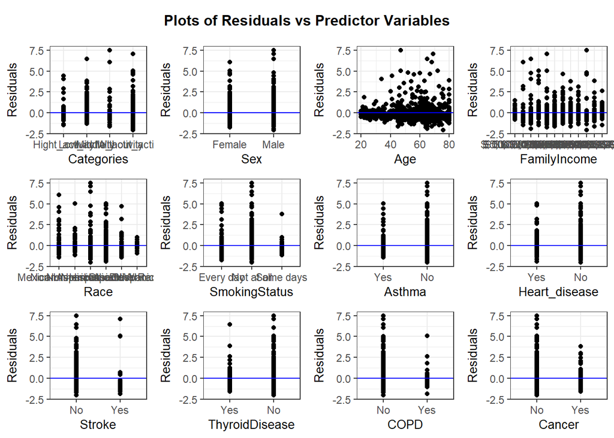

#поправка на гетероскедастичность

```
##
## t test of coefficients:
##
##                                  Estimate Std. Error t value  Pr(>|t|)
## (Intercept)                     5.8050786  0.3248352 17.8708 < 2.2e-16 ***
## CategoriesLow_activity         -0.2300749  0.1173061 -1.9613 0.0501544 .
## CategoriesMiddle_activity      -0.0627746  0.1640175 -0.3827 0.7020112
## CategoriesWithout_activity      0.0184683  0.1375850  0.1342 0.8932496
## SexMale                         0.0142671  0.0808284  0.1765 0.8599325
## Age                             0.0124133  0.0021154  5.8682 6.222e-09 ***
## FamilyIncome$ 5,000 to $ 9,999  0.4911588  0.2633548  1.8650 0.0625107 .
## FamilyIncome$10,000 to $14,999  0.3509164  0.2069473  1.6957 0.0902977 .
## FamilyIncome$100,000 and Over   0.2918152  0.1565565  1.8640 0.0626578 .
## FamilyIncome$15,000 to $19,999  0.3708021  0.2060200  1.7998 0.0722268 .
## FamilyIncome$20,000 to $24,999  0.1763740  0.1590328  1.1090 0.2677131
## FamilyIncome$25,000 to $34,999  0.4084789  0.1643061  2.4861 0.0130990 *
## FamilyIncome$35,000 to $44,999  0.1473566  0.1502128  0.9810 0.3268676
## FamilyIncome$45,000 to $54,999  0.2751036  0.1698891  1.6193 0.1057359
## FamilyIncome$55,000 to $64,999  0.5427642  0.2617979  2.0732 0.0384405 *
## FamilyIncome$65,000 to $74,999  0.4098394  0.1902490  2.1542 0.0314915 *
## FamilyIncome$75,000 to $99,999  0.1262409  0.1533972  0.8230 0.4107480
## RaceNon-HispanicAsian          -0.0851810  0.1550334 -0.5494 0.5828444
## RaceNon-HispanicBlack          -0.0081634  0.1622966 -0.0503 0.9598951
## RaceNon-HispanicWhite          -0.4375039  0.1297282 -3.3725 0.0007773 ***
## RaceOtherHispanic              -0.2736188  0.1655102 -1.6532 0.0986477 .
## RaceOtherRace                  -0.4902002  0.1624167 -3.0182 0.0026159 **
## SmokingStatusNot at all        -0.0427174  0.1022004 -0.4180 0.6760649
## SmokingStatusSome days         -0.0551881  0.1733096 -0.3184 0.7502290
## AsthmaNo                       -0.0270209  0.0840851 -0.3214 0.7480195
## Heart_diseaseNo                -0.6351236  0.1668832 -3.8058 0.0001511 ***
## StrokeYes                       0.4241123  0.3613831  1.1736 0.2408783
## ThyroidDiseaseNo                0.0381667  0.1141112  0.3345 0.7381049
## COPDYes                        -0.2580580  0.1807378 -1.4278 0.1537008
## CancerYes                       0.1060697  0.1075361  0.9864 0.3242237
## ---
## Signif. codes:  0 '***' 0.001 '**' 0.01 '*' 0.05 '.' 0.1 ' ' 1
```

С поправкой на гетероскедастичность значимость факторов на гемоглобин немного изменилась изменилась. Но так же остались значимыми: возраст, раса, заболевания сердца

#С ковариатами (без деления на категории, количественная переменная activity)

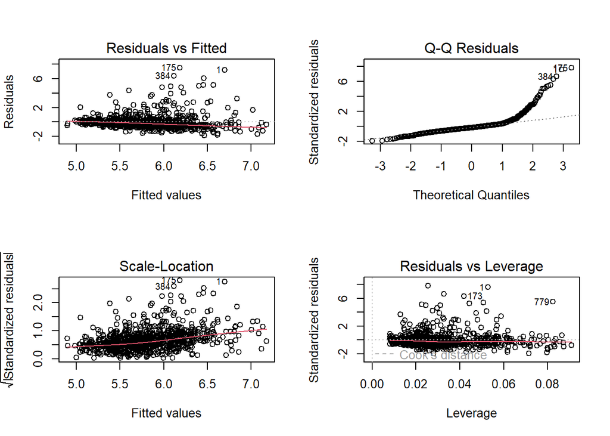

```
##
## Call:
## lm(formula = Hb ~ Activity + Sex + Race + Age + FamilyIncome +
##     SmokingStatus + Asthma + Heart_disease + Stroke + ThyroidDisease +
##     COPD + Cancer, data = ready_data)
##
## Coefficients:
##                    (Intercept)                        Activity
##                       5.598191                        0.003849
##                        SexMale           RaceNon-HispanicAsian
##                      -0.001516                       -0.088302
##          RaceNon-HispanicBlack           RaceNon-HispanicWhite
##                       0.002083                       -0.421323
##              RaceOtherHispanic                   RaceOtherRace
##                      -0.254285                       -0.466926
##                            Age  FamilyIncome$ 5,000 to $ 9,999
##                       0.013392                        0.521593
## FamilyIncome$10,000 to $14,999   FamilyIncome$100,000 and Over
##                       0.345259                        0.264993
## FamilyIncome$15,000 to $19,999  FamilyIncome$20,000 to $24,999
##                       0.350362                        0.169313
## FamilyIncome$25,000 to $34,999  FamilyIncome$35,000 to $44,999
##                       0.411779                        0.134100
## FamilyIncome$45,000 to $54,999  FamilyIncome$55,000 to $64,999
##                       0.228851                        0.520554
## FamilyIncome$65,000 to $74,999  FamilyIncome$75,000 to $99,999
##                       0.398507                        0.117412
##        SmokingStatusNot at all          SmokingStatusSome days
##                      -0.044578                       -0.056548
##                       AsthmaNo                 Heart_diseaseNo
##                      -0.030624                       -0.633386
##                      StrokeYes                ThyroidDiseaseNo
##                       0.497567                        0.038878
##                        COPDYes                       CancerYes
##                      -0.237474                        0.084678
```

```
##                    (Intercept)                       Activity
##                    5.598191064                    0.003849011
##                        SexMale          RaceNon-HispanicAsian
##                   -0.001516177                   -0.088302411
##          RaceNon-HispanicBlack          RaceNon-HispanicWhite
##                    0.002083478                   -0.421323129
##              RaceOtherHispanic                  RaceOtherRace
##                   -0.254284575                   -0.466926407
##                            Age FamilyIncome$ 5,000 to $ 9,999
##                    0.013392114                    0.521593268
## FamilyIncome$10,000 to $14,999  FamilyIncome$100,000 and Over
##                    0.345259080                    0.264992643
## FamilyIncome$15,000 to $19,999 FamilyIncome$20,000 to $24,999
##                    0.350361772                    0.169312776
## FamilyIncome$25,000 to $34,999 FamilyIncome$35,000 to $44,999
##                    0.411778724                    0.134100260
## FamilyIncome$45,000 to $54,999 FamilyIncome$55,000 to $64,999
##                    0.228850521                    0.520553993
## FamilyIncome$65,000 to $74,999 FamilyIncome$75,000 to $99,999
##                    0.398506970                    0.117412087
##        SmokingStatusNot at all         SmokingStatusSome days
##                   -0.044577952                   -0.056547980
##                       AsthmaNo                Heart_diseaseNo
##                   -0.030623891                   -0.633386459
##                      StrokeYes               ThyroidDiseaseNo
##                    0.497566564                    0.038878313
##                        COPDYes                      CancerYes
##                   -0.237473811                    0.084678209
```

```
##
## Call:
## lm(formula = Hb ~ Activity + Sex + Race + Age + FamilyIncome +
##     SmokingStatus + Asthma + Heart_disease + Stroke + ThyroidDisease +
##     COPD + Cancer, data = ready_data)
##
## Residuals:
##     Min      1Q  Median      3Q     Max
## -1.8674 -0.4483 -0.1746  0.1539  7.5170
##
## Coefficients:
##                                 Estimate Std. Error t value Pr(>|t|)
## (Intercept)                     5.598191   0.321619  17.406  < 2e-16 ***
## Activity                        0.003849   0.002392   1.609 0.108006
## SexMale                        -0.001516   0.074221  -0.020 0.983707
## RaceNon-HispanicAsian          -0.088302   0.153904  -0.574 0.566282
## RaceNon-HispanicBlack           0.002083   0.123882   0.017 0.986585
## RaceNon-HispanicWhite          -0.421323   0.111094  -3.793 0.000159 ***
## RaceOtherHispanic              -0.254285   0.150698  -1.687 0.091883 .
## RaceOtherRace                  -0.466926   0.225678  -2.069 0.038836 *
## Age                             0.013392   0.002411   5.555 3.68e-08 ***
## FamilyIncome$ 5,000 to $ 9,999  0.521593   0.262343   1.988 0.047095 *
## FamilyIncome$10,000 to $14,999  0.345259   0.236612   1.459 0.144870
## FamilyIncome$100,000 and Over   0.264993   0.222454   1.191 0.233884
## FamilyIncome$15,000 to $19,999  0.350362   0.233610   1.500 0.134028
## FamilyIncome$20,000 to $24,999  0.169313   0.234838   0.721 0.471113
## FamilyIncome$25,000 to $34,999  0.411779   0.228045   1.806 0.071305 .
## FamilyIncome$35,000 to $44,999  0.134100   0.229385   0.585 0.558961
## FamilyIncome$45,000 to $54,999  0.228851   0.236799   0.966 0.334090
## FamilyIncome$55,000 to $64,999  0.520554   0.245916   2.117 0.034555 *
## FamilyIncome$65,000 to $74,999  0.398507   0.250870   1.588 0.112530
## FamilyIncome$75,000 to $99,999  0.117412   0.237464   0.494 0.621116
## SmokingStatusNot at all        -0.044578   0.097541  -0.457 0.647771
## SmokingStatusSome days         -0.056548   0.196952  -0.287 0.774091
## AsthmaNo                       -0.030624   0.090527  -0.338 0.735228
## Heart_diseaseNo                -0.633386   0.128216  -4.940 9.33e-07 ***
## StrokeYes                       0.497567   0.179680   2.769 0.005737 **
## ThyroidDiseaseNo                0.038878   0.099939   0.389 0.697353
## COPDYes                        -0.237474   0.173859  -1.366 0.172316
## CancerYes                       0.084678   0.109014   0.777 0.437505
## ---
## Signif. codes:  0 '***' 0.001 '**' 0.01 '*' 0.05 '.' 0.1 ' ' 1
##
## Residual standard error: 0.9721 on 888 degrees of freedom
## Multiple R-squared:  0.1439, Adjusted R-squared:  0.1178
## F-statistic: 5.527 on 27 and 888 DF,  p-value: < 2.2e-16
```

```
## # A tibble: 28 × 7
##    term                 estimate std.error statistic  p.value conf.low conf.high
##    <chr>                   <dbl>     <dbl>     <dbl>    <dbl>    <dbl>     <dbl>
##  1 (Intercept)           5.60      0.322     17.4    1.31e-58  4.97e+0   6.23
##  2 Activity              0.00385   0.00239    1.61   1.08e- 1 -8.46e-4   0.00854
##  3 SexMale              -0.00152   0.0742    -0.0204 9.84e- 1 -1.47e-1   0.144
##  4 RaceNon-HispanicAsi… -0.0883    0.154     -0.574  5.66e- 1 -3.90e-1   0.214
##  5 RaceNon-HispanicBla…  0.00208   0.124      0.0168 9.87e- 1 -2.41e-1   0.245
##  6 RaceNon-HispanicWhi… -0.421     0.111     -3.79   1.59e- 4 -6.39e-1  -0.203
##  7 RaceOtherHispanic    -0.254     0.151     -1.69   9.19e- 2 -5.50e-1   0.0415
##  8 RaceOtherRace        -0.467     0.226     -2.07   3.88e- 2 -9.10e-1  -0.0240
##  9 Age                   0.0134    0.00241    5.55   3.68e- 8  8.66e-3   0.0181
## 10 FamilyIncome$ 5,000…  0.522     0.262      1.99   4.71e- 2  6.71e-3   1.04
## # ℹ 18 more rows
```

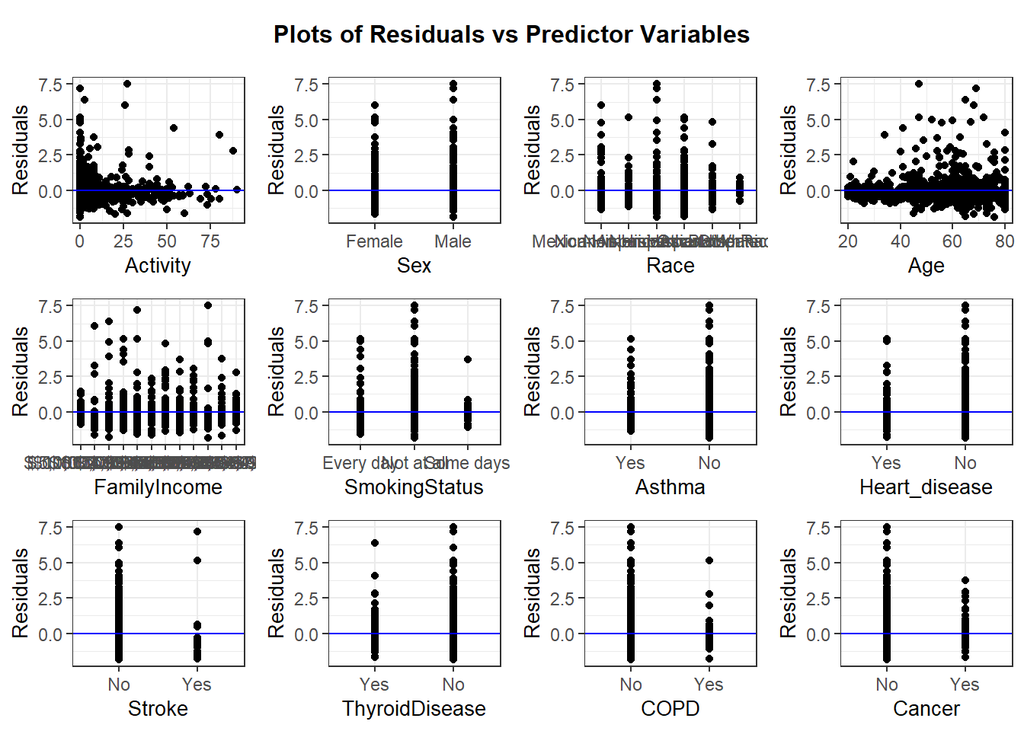

Видно, что для переменной Activity распределение остатков неравномерно, образуется “рукав”, => нелинейная зависимость (возможно, квадратичная функция зависимости)

#С поправкой на гетероскедастичность

[output not shown]

#С поправкой на гетероскедастичность и нелинейность

```
##
## Call:
## lm(formula = Hb ~ Activity + I(Activity^2) + Sex + FamilyIncome +
##     Race + SmokingStatus + Asthma + Heart_disease + Stroke +
##     ThyroidDisease + COPD + Cancer, data = ready_data)
##
## Residuals:
##     Min      1Q  Median      3Q     Max
## -1.9469 -0.4633 -0.1775  0.1707  7.6548
##
## Coefficients:
##                                  Estimate Std. Error t value Pr(>|t|)
## (Intercept)                     6.433e+00  2.863e-01  22.474  < 2e-16 ***
## Activity                       -1.388e-02  5.836e-03  -2.379 0.017555 *
## I(Activity^2)                   2.839e-04  9.874e-05   2.875 0.004134 **
## SexMale                        -1.023e-01  7.227e-02  -1.416 0.157059
## FamilyIncome$ 5,000 to $ 9,999  5.695e-01  2.654e-01   2.146 0.032171 *
## FamilyIncome$10,000 to $14,999  4.032e-01  2.394e-01   1.684 0.092474 .
## FamilyIncome$100,000 and Over   3.112e-01  2.254e-01   1.380 0.167819
## FamilyIncome$15,000 to $19,999  4.341e-01  2.362e-01   1.838 0.066422 .
## FamilyIncome$20,000 to $24,999  2.395e-01  2.380e-01   1.006 0.314474
## FamilyIncome$25,000 to $34,999  4.758e-01  2.310e-01   2.059 0.039746 *
## FamilyIncome$35,000 to $44,999  2.308e-01  2.316e-01   0.996 0.319348
## FamilyIncome$45,000 to $54,999  3.201e-01  2.396e-01   1.336 0.181896
## FamilyIncome$55,000 to $64,999  5.857e-01  2.490e-01   2.352 0.018881 *
## FamilyIncome$65,000 to $74,999  4.766e-01  2.543e-01   1.874 0.061251 .
## FamilyIncome$75,000 to $99,999  1.305e-01  2.405e-01   0.543 0.587469
## RaceNon-HispanicAsian          -1.325e-01  1.556e-01  -0.852 0.394386
## RaceNon-HispanicBlack          -3.422e-03  1.256e-01  -0.027 0.978266
## RaceNon-HispanicWhite          -4.190e-01  1.126e-01  -3.721 0.000211 ***
## RaceOtherHispanic              -2.761e-01  1.528e-01  -1.807 0.071137 .
## RaceOtherRace                  -5.324e-01  2.285e-01  -2.330 0.020025 *
## SmokingStatusNot at all         6.160e-02  9.804e-02   0.628 0.529938
## SmokingStatusSome days         -1.557e-02  2.000e-01  -0.078 0.937950
## AsthmaNo                        2.688e-03  9.140e-02   0.029 0.976545
## Heart_diseaseNo                -7.576e-01  1.276e-01  -5.937 4.16e-09 ***
## StrokeYes                       5.986e-01  1.809e-01   3.309 0.000976 ***
## ThyroidDiseaseNo               -6.601e-03  1.008e-01  -0.066 0.947783
## COPDYes                        -2.244e-01  1.760e-01  -1.275 0.202727
## CancerYes                       2.296e-01  1.070e-01   2.146 0.032164 *
## ---
## Signif. codes:  0 '***' 0.001 '**' 0.01 '*' 0.05 '.' 0.1 ' ' 1
##
## Residual standard error: 0.9843 on 888 degrees of freedom
## Multiple R-squared:  0.1223, Adjusted R-squared:  0.09561
## F-statistic: 4.583 on 27 and 888 DF,  p-value: 2.987e-13
```

```
##
## t test of coefficients:
##
##                                   Estimate  Std. Error t value  Pr(>|t|)
## (Intercept)                     6.43317179  0.26485544 24.2894 < 2.2e-16 ***
## Activity                       -0.01388485  0.00762687 -1.8205 0.0690167 .
## I(Activity^2)                   0.00028390  0.00014169  2.0037 0.0454043 *
## SexMale                        -0.10234883  0.07657067 -1.3367 0.1816765
## FamilyIncome$ 5,000 to $ 9,999  0.56952109  0.28010890  2.0332 0.0423280 *
## FamilyIncome$10,000 to $14,999  0.40319577  0.21174490  1.9042 0.0572126 .
## FamilyIncome$100,000 and Over   0.31117084  0.16679403  1.8656 0.0624270 .
## FamilyIncome$15,000 to $19,999  0.43411049  0.20801644  2.0869 0.0371814 *
## FamilyIncome$20,000 to $24,999  0.23948810  0.17015289  1.4075 0.1596328
## FamilyIncome$25,000 to $34,999  0.47577553  0.17571686  2.7076 0.0069069 **
## FamilyIncome$35,000 to $44,999  0.23077498  0.16167219  1.4274 0.1538089
## FamilyIncome$45,000 to $54,999  0.32011642  0.18210125  1.7579 0.0791084 .
## FamilyIncome$55,000 to $64,999  0.58567515  0.26672791  2.1958 0.0283659 *
## FamilyIncome$65,000 to $74,999  0.47656829  0.19999534  2.3829 0.0173865 *
## FamilyIncome$75,000 to $99,999  0.13053343  0.16542517  0.7891 0.4302768
## RaceNon-HispanicAsian          -0.13254662  0.15742907 -0.8419 0.4000454
## RaceNon-HispanicBlack          -0.00342215  0.16309746 -0.0210 0.9832645
## RaceNon-HispanicWhite          -0.41904258  0.12997189 -3.2241 0.0013098 **
## RaceOtherHispanic              -0.27610046  0.16957055 -1.6282 0.1038301
## RaceOtherRace                  -0.53241825  0.16043678 -3.3186 0.0009416 ***
## SmokingStatusNot at all         0.06160159  0.10184164  0.6049 0.5454158
## SmokingStatusSome days         -0.01557491  0.17350553 -0.0898 0.9284934
## AsthmaNo                        0.00268806  0.08601951  0.0312 0.9750776
## Heart_diseaseNo                -0.75761598  0.16474909 -4.5986 4.871e-06 ***
## StrokeYes                       0.59859576  0.37023835  1.6168 0.1062799
## ThyroidDiseaseNo               -0.00660107  0.11844777 -0.0557 0.9555696
## COPDYes                        -0.22439216  0.18227330 -1.2311 0.2186207
## CancerYes                       0.22961656  0.10319864  2.2250 0.0263321 *
## ---
## Signif. codes:  0 '***' 0.001 '**' 0.01 '*' 0.05 '.' 0.1 ' ' 1
```

#Задание 5. Точеченая и интервальная оценка Для модели без ковариат (с категориальной переменной Activity) p-value < 0,05 только для категории людей без физ нагрузки. ДИ не включает 0 (0,022 ; 0,55). Для остальных категорий физ нагрузки p-value > 0,05 (ДИ включает 0), что говорит о том, что продолжительность физ нагрузки не влияет на уровень гликированного гемоглобина, но влияет сам факт присутствия физ нагрузки. При этом R2 данной модели был 0,02.

#Задание 6

```
##
##  Pearson's product-moment correlation
##
## data:  ready_data$Hb and ready_data$Activity
## t = -0.49827, df = 914, p-value = 0.6184
## alternative hypothesis: true correlation is not equal to 0
## 95 percent confidence interval:
##  -0.08116699  0.04834702
## sample estimates:
##         cor
## -0.01647911
```

Между гликированием гемоглобина и физической активностью практически нет корреляции, P-value > 0.05. Но она не равна 0, есть небольшая отрицательная корреляция. Эта небольшая корреляция отражается в регрессионном анализе

```
##
##  Pearson's product-moment correlation
##
## data:  ready_data$Hb[ready_data$Hb > 9] and ready_data$Activity[ready_data$Hb > 9]
## t = -0.98398, df = 19, p-value = 0.3375
## alternative hypothesis: true correlation is not equal to 0
## 95 percent confidence interval:
##  -0.5952987  0.2337026
## sample estimates:
##        cor
## -0.2201993
```

При том, если убрать низкие значения гликированного гемоглобина (отфильтовать значения выше среднего уровня гликированного геомглобина),то будет более выраженная отрицательная корреляция

Статистически значимой корреляции нет. При фильтрации значений корреляция так же может меняться (может быть отрицательной или положительной). То есть длительность физической активности не оказывает какой-то однозначный эффект на уровень гликированного гемоглобина.

#Задание 7

```
##
## Call:
## lm(formula = Hb ~ Categories * Sex + FamilyIncome + Race + SmokingStatus +
##     Asthma + Heart_disease + Stroke + ThyroidDisease + COPD +
##     Cancer, data = ready_data)
##
## Residuals:
##     Min      1Q  Median      3Q     Max
## -2.0073 -0.4668 -0.1825  0.1729  7.4914
##
## Coefficients:
##                                     Estimate Std. Error t value Pr(>|t|)
## (Intercept)                         6.513846   0.394980  16.492  < 2e-16 ***
## CategoriesLow_activity             -0.167841   0.295296  -0.568  0.56992
## CategoriesMiddle_activity          -0.037135   0.339944  -0.109  0.91304
## CategoriesWithout_activity          0.106031   0.299727   0.354  0.72360
## SexMale                            -0.129251   0.313267  -0.413  0.68001
## FamilyIncome$ 5,000 to $ 9,999      0.542103   0.265843   2.039  0.04173 *
## FamilyIncome$10,000 to $14,999      0.401382   0.239540   1.676  0.09416 .
## FamilyIncome$100,000 and Over       0.309924   0.225240   1.376  0.16918
## FamilyIncome$15,000 to $19,999      0.434160   0.236642   1.835  0.06689 .
## FamilyIncome$20,000 to $24,999      0.210437   0.237579   0.886  0.37599
## FamilyIncome$25,000 to $34,999      0.439334   0.231290   1.899  0.05782 .
## FamilyIncome$35,000 to $44,999      0.231122   0.231735   0.997  0.31887
## FamilyIncome$45,000 to $54,999      0.339241   0.239318   1.418  0.15668
## FamilyIncome$55,000 to $64,999      0.582354   0.248921   2.340  0.01953 *
## FamilyIncome$65,000 to $74,999      0.443658   0.253878   1.748  0.08089 .
## FamilyIncome$75,000 to $99,999      0.116242   0.240360   0.484  0.62878
## RaceNon-HispanicAsian              -0.132118   0.155533  -0.849  0.39586
## RaceNon-HispanicBlack              -0.031838   0.125178  -0.254  0.79929
## RaceNon-HispanicWhite              -0.450010   0.112417  -4.003 6.78e-05 ***
## RaceOtherHispanic                  -0.329416   0.152322  -2.163  0.03084 *
## RaceOtherRace                      -0.613987   0.227578  -2.698  0.00711 **
## SmokingStatusNot at all             0.035312   0.097472   0.362  0.71723
## SmokingStatusSome days             -0.047338   0.199637  -0.237  0.81262
## AsthmaNo                            0.006546   0.091586   0.071  0.94303
## Heart_diseaseNo                    -0.754485   0.127945  -5.897 5.27e-09 ***
## StrokeYes                           0.511720   0.182675   2.801  0.00520 **
## ThyroidDiseaseNo                   -0.010828   0.100752  -0.107  0.91444
## COPDYes                            -0.247987   0.176064  -1.409  0.15933
## CancerYes                           0.244324   0.107211   2.279  0.02291 *
## CategoriesLow_activity:SexMale      0.024483   0.324688   0.075  0.93991
## CategoriesMiddle_activity:SexMale   0.034079   0.380910   0.089  0.92873
## CategoriesWithout_activity:SexMale  0.070531   0.339386   0.208  0.83542
## ---
## Signif. codes:  0 '***' 0.001 '**' 0.01 '*' 0.05 '.' 0.1 ' ' 1
##
## Residual standard error: 0.9836 on 884 degrees of freedom
## Multiple R-squared:  0.1276, Adjusted R-squared:  0.097
## F-statistic: 4.171 on 31 and 884 DF,  p-value: 7.623e-13
```

```
## # A tibble: 32 × 7
##    term                 estimate std.error statistic  p.value conf.low conf.high
##    <chr>                   <dbl>     <dbl>     <dbl>    <dbl>    <dbl>     <dbl>
##  1 (Intercept)            6.51       0.395    16.5   1.78e-53   5.74       7.29
##  2 CategoriesLow_activ…  -0.168      0.295    -0.568 5.70e- 1  -0.747      0.412
##  3 CategoriesMiddle_ac…  -0.0371     0.340    -0.109 9.13e- 1  -0.704      0.630
##  4 CategoriesWithout_a…   0.106      0.300     0.354 7.24e- 1  -0.482      0.694
##  5 SexMale               -0.129      0.313    -0.413 6.80e- 1  -0.744      0.486
##  6 FamilyIncome$ 5,000…   0.542      0.266     2.04  4.17e- 2   0.0203     1.06
##  7 FamilyIncome$10,000…   0.401      0.240     1.68  9.42e- 2  -0.0688     0.872
##  8 FamilyIncome$100,00…   0.310      0.225     1.38  1.69e- 1  -0.132      0.752
##  9 FamilyIncome$15,000…   0.434      0.237     1.83  6.69e- 2  -0.0303     0.899
## 10 FamilyIncome$20,000…   0.210      0.238     0.886 3.76e- 1  -0.256      0.677
## # ℹ 22 more rows
```

Пол не является модификатором эффекта, p-value > 0.05.

#Задание 8 Полученные результаты не соответствуют первоначальной гипотезе. Так как не получилось доказать, что при увеличении физической активности снижается уровень гликированного гемоглобина. Можно сказать, что наличие в принципе физической активности статистичеси значимо влияет на уровень гликированного геомоглобина.

Для модели без ковариат (с категориальной переменной Activity) p-value < 0,05 только для категории людей без физ нагрузки. ДИ не включает 0 (0,022 ; 0,55). Для остальных категорий физ нагрузки p-value > 0,05 (ДИ включает 0), что говорит о том, что продолжительность физ нагрузки не влияет на уровень гликированного гемоглобина, но влияет сам факт присутствия физ нагрузки. При этом R2 данной модели был 0,02.

Также была построена модель с ковариатами. При включении ковариат R2 стал равен 0,15. Были определены факторы, влияющие на уровень гликированного гемоглобина. Но при этом уровень физ нагрузки значимо не влияет. Такая же ситуация наблюдалась при поправке на гетероскедастичность. Кроме того проверялась модель для переменной физ активности (количественной, без деления на категории). Переменная физ активности не была значимой, но при использовании квадратичной функции (предполагаем, что зависимость гемоглобин-физ нагрузка нелинейна) фактор физ нагрузки становится значимым и увеличивается R2.